# Intro to Conjoint Experiments | Lab - 2

# 1 Conjoint SDT

1. We use a python program developed by Anton Strezhnev (NYU) called **Conjointsdt**
2. Deals with several aspects of out CJ design
   - PHP script for randomization (external server)
   - JS script for randomization (only for Qualtrics)
   - Qualtrics HTML Tables
   - The survey design in R (in fact, it does not)

# 2 Attributes and Levels in Conjointsdt

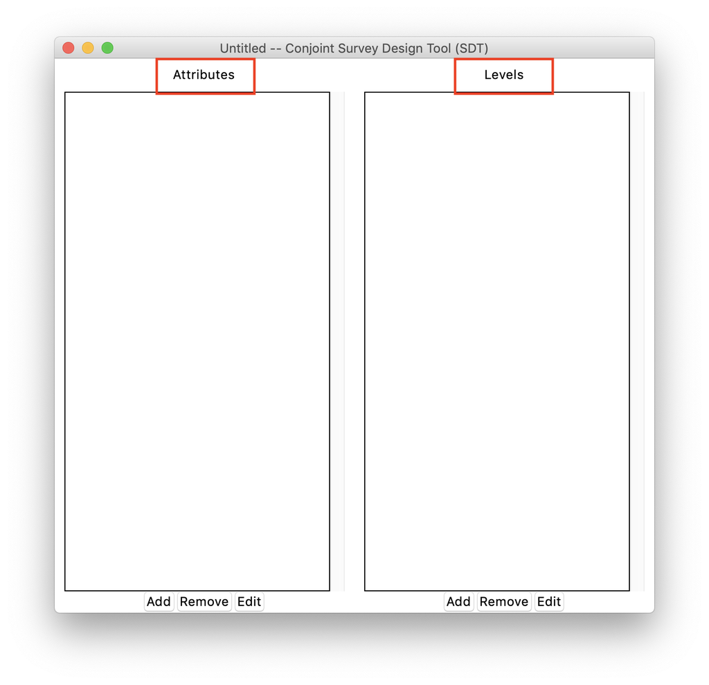

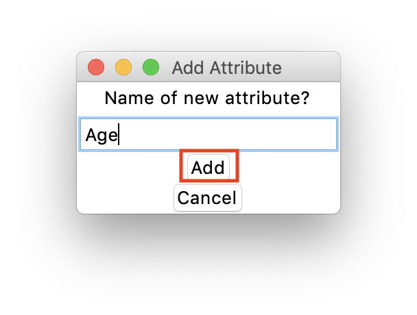

# 3 Save the baseline design

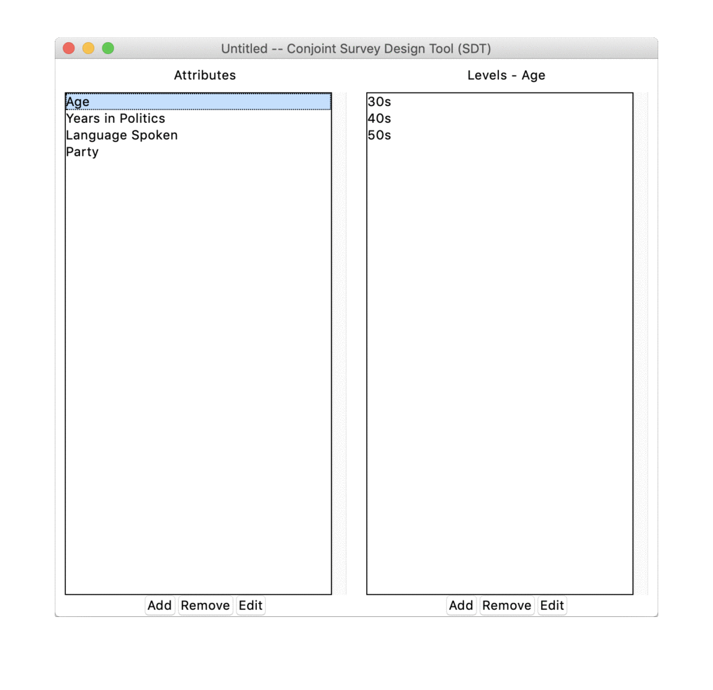

1. Always save the design in case something get lost
2. File -> Save -> name_of_the_design.sdt

# 4 Choice-set

1. Edit -> Settings
2. Randomized Order of attributes per each respondent
   - That is, we keep the attribute order the same per each respondent
   - Ease the cognitive load
3. Use Weighted Randomization
   - Allow the usage of a specific marginal distribution for the levels
4. Number of Tasks
   - How many times a single respondents performs a CJ
5. Number of Profiles
   - Usually two Profile at time
   - Q: Can you think of a design where 3 profiles make sense?

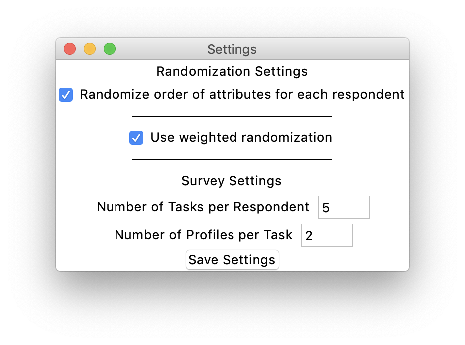

# 5 Attribute order [Advanced]

1. Group together similar Attributes (e.g. all attributes related to Job in @hainmueller_causal_2014)
2. Usually, used in big designs to reduce the cognitive burden of the respondent
3. Edit -> Restrictions -> Attribute Order Constrains

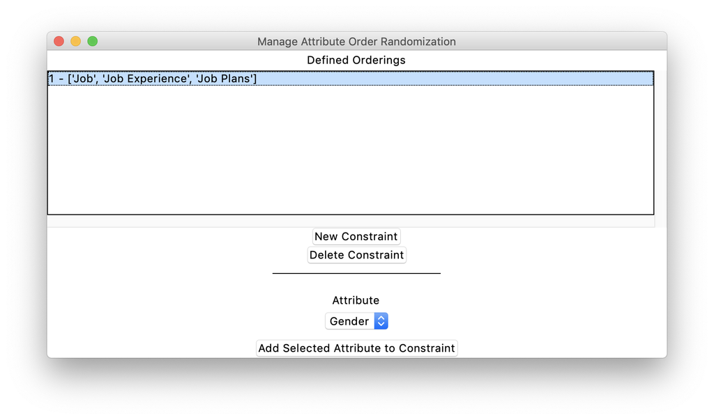

# 6 Weights for different distribution of the attributes/level [Advanced]

1. File -> Randomization Weights
2. Impute the proportion from 0 to 1
3. If a levels appear 20% of the time, 0.20
4. **The sum of the weights should be equal to 1**
5. Rememberer to save: File -> Save -> name_of_the_design.sdt

## 6.1 Weights in Conjointsdt

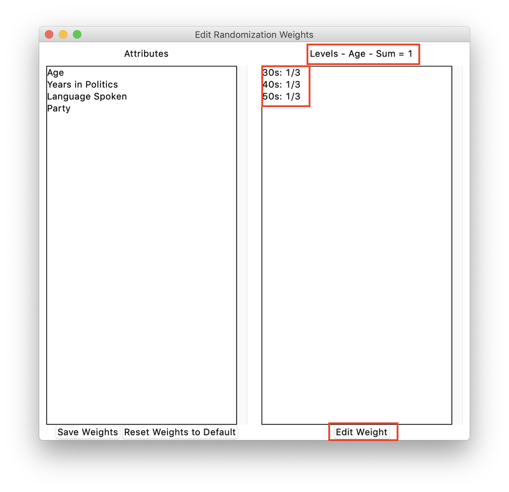

# 7 Implement randomization restrictions [Advanced]

1. Q: Is it realistic that a candidate in its 30s has 20 years of political experience?
2. Set the conditional probability of displaying Age=30 AND Experience=20 equal to 0
3. Edit -> Restrictions -> Add Selected levels to Restriction
4. Rememberer to save: File -> Save -> name_of_the_design.sdt

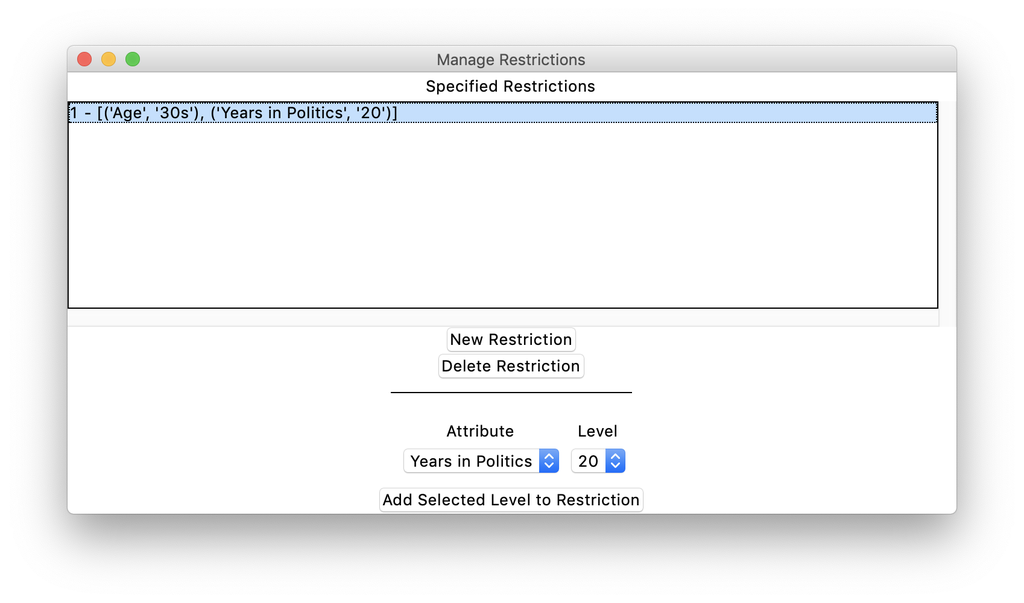

# 8 Exporting

1. Menu -> Edit -> Export to PHP
   - This is going to be on a server for the randomization
   - php_script_name_of_the_design.php
2. Menu -> Edit -> Export to Java Script
   - This is going to be directly on Qualtrics
   - php_script_name_of_the_design.js
3. Menu -> Edit -> Export to Qualtrics
   - HTML tables that will be fed by the PHP/JS
   - Task_1_name_of_the_design.html
4. Menu -> Edit -> Export to R
   - Used in the Modelling Part
   - design_R_name_of_the_design.dat